# Uma Interpolação de Volatilidades Livre de Arbitragem

05/2019

## Introdução

- Opção: contrato que dá direito ao comprador e obrigação ao lançador
- Opção de compra europeia: titular tem direito de comprar apenas no final do contrato
- Contrato com ativo objeto, prazo, preço de exercício

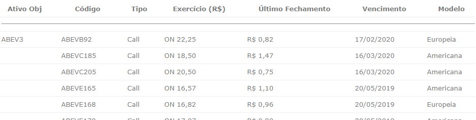

- Qual o preço justo teórico desses contratos?

## Black & Scholes

- Assume distribuição log-normal para preço do ativo objeto no futuro

\[ c_{BS} \left( S, \tau, K, r, \sigma, q \right) = e^{-r\tau} \left[ FN(d_1) - KN(d_2) \right] \] \[ F = Se^{(r - q)\tau} \] \[ d_1 = \dfrac{\log(F/K)}{\sigma \sqrt{\tau}} + \dfrac{\sigma \sqrt{\tau}}{2} \] \[ d_2 = d_1 - \sigma \sqrt{\tau} \] \[ N(x) = \int_{-\infty}^x \dfrac{1}{\sqrt{2\pi}} \exp \left( \dfrac{-t^2}{2} \right) dt \]

## Volatilidade Implícita

- As suposições não se verificam totalmente na realidade
- Variável mais difícil de medir é a volatilidade, e é nela que recai a imperfeição do modelo

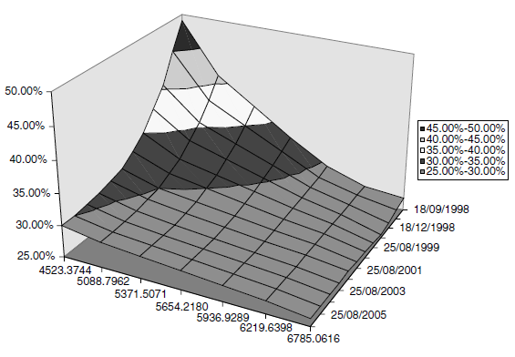

- Volatilidade não se mantém constante

## Não Arbitragem - Derivadas

- É de interesse montar superfície e sorrisos de volatilidade
- Métodos comuns de interpolação não seguem restrições importantes

## Não Arbitragem - Limites

- Nosso caso trata dos casos limite, onde também temos restrições

\[ c\left( \tau, 0 \right) := \lim_{K \rightarrow 0} c\left( \tau, K \right) = S \] \[ c\left( \tau, \infty \right) := \lim_{K \rightarrow \infty} c\left( \tau, K \right) = 0 \] \[ c\left( 0, K \right) := \lim_{\tau \rightarrow 0} c\left( \tau, K \right) = S \] \[ c\left( \infty, K \right) := \lim_{\tau \rightarrow \infty} c\left( \tau, K \right) = 0 \]

## Interpolação de Volatilidades

- Fixado ativo objeto e prazo e dados \((k_i, c_i)_{1 \leq i \leq n}\) pelo mercado
- Acrescentamos \(k_{n+1} = \infty\), \(k_0 = 0\), \(c_{n+1} = 0\) e \(c_0\) é o spot, preço do ativo objeto e verificamos não arbitragem

\[ 0 = c_{n+1} = k_0 < k_1 < \dots < k_n < k_{n+1} = \infty \]

\[ -1 \leq \dfrac{c_i - c_{i-1}}{k_i - k_{i-1}} \leq \dfrac{c_{i+1} - c_i}{k_{i+1} - k_i} \leq 0\text{, para } 1 \leq i \leq n \]

- Escolher parâmetros \(f_i\), \(\Sigma_i\), \(a_i\), \(b_i\), para cada \([k_{i-1}, k_{i}[\), \(1 \leq i \leq n+1\), lembrando um spline

## Interpolação de Kahalé

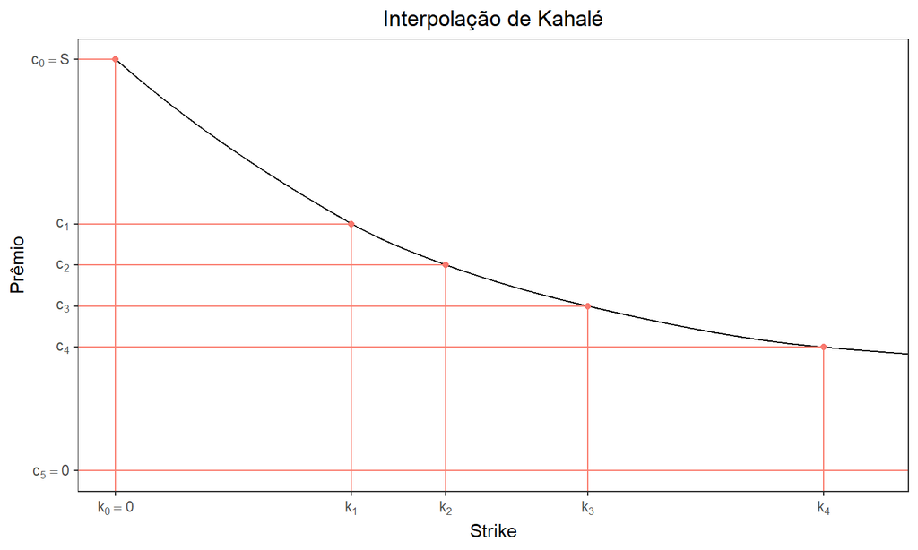

## Função Interpoladora

\[ c(k; f, \Sigma, a, b) = fN(d_1) - kN(d_2) + ak + b \] \[ c'(k; f, \Sigma, a, b) = -N(d_2) + a \] \[ c''(k; f, \Sigma, a, b) = \dfrac{N'(d_2)}{k\Sigma} \] \[ d_1 = \dfrac{\log(f/k)}{\Sigma} + \dfrac{\Sigma}{2} \] \[ d_2 = d_1 - \Sigma \] \[ N(x) = \int_{-\infty}^x \dfrac{1}{\sqrt{2\pi}} \exp \left( \dfrac{-t^2}{2} \right) dt \]

## Interpolação C<sup>1</sup>

- Existência e unicidade demonstrada
- Liberdade de escolher \((c'_i)_{0 \leq i \leq n + 1}\) dentro das restrições de não arbitragem

\[ c'_0 = -1 \text{, } c'_{n+1} = 0 \]

\[ c'_i < \dfrac{c_{i+1} - c_i}{k_{i+1} - k_i} < c'_{i+1} \text{, para } 0 \leq i \leq n \]

## Interpolação C<sup>1</sup>

- Resolver para cada intervalo \([k_i, k_{i+1}[\), \(0 \leq i \leq n\) o sistema

\[ \begin{cases} c(k_i; f_i, \Sigma_i, a_i, b_i) = c_i \\ c(k_{i+1}; f_i, \Sigma_i, a_i, b_i) = c_{i+1} \\ c'(k_i; f_i, \Sigma_i, a_i, b_i) = c'_i \\ c'(k_{i+1}; f_i, \Sigma_i, a_i, b_i) = c'_{i+1} \end{cases} \]

- Poder escolher o valor das derivadas significa que ainda sobram graus de liberdade

## Intervalos Extremos

- O intervalos extremos \([k_0, k_1[\) e \([k_n, k_{n+1}[\) podem ter seus sistemas simplificados para resolução numérica de apenas uma equação
- Assim, verificamos que sempre ocorre \(a_1 = 0\), \(a_{n+1} = 0\) e \(b_{n+1} = 0\)
- Graus de liberdade sobrando nos extremos

## Interpolação C<sup>2</sup>

- Duas maneiras de produzir, apenas uma no artigo
- Existência demonstrada e unicidade conjecturada
- Não é mais possível a resolução intervalo a intervalo, apenas um sistema de \(4(n+1)\) equações
- Em cada \(k_i\), \(1 \leq i \leq n\), queremos

\[ \begin{cases} c(k_i; f_{i}, \Sigma_{i}, a_{i}, b_{i}) = c_i \\ c(k_i; f_{i+1}, \Sigma_{i+1}, a_{i+1}, b_{i+1}) = c_i \\ c'(k_i; f_{i}, \Sigma_{i}, a_{i}, b_{i}) = c'(k_i; f_{i+1}, \Sigma_{i+1}, a_{i+1}, b_{i+1}) \\ c''(k_i; f_{i}, \Sigma_{i}, a_{i}, b_{i}) = c''(k_i; f_{i+1}, \Sigma_{i+1}, a_{i+1}, b_{i+1}) \end{cases} \]

## Extremos Interpolação C<sup>2</sup>

- Graus de liberdade dos extremos são usados agora
- Para \(k_0\) queremos

\[ \begin{cases} c(0; f_1, \Sigma_1, a_1, b_1) = c_0 = S \\ c'(0; f_1, \Sigma_1, a_1, b_1) = -1 \end{cases} \]

- E para \(k_{n+1}\)

\[ \begin{cases} c(\infty; f_{n+1}, \Sigma_{n+1}, a_{n+1}, b_{n+1}) = c_{n+1} = 0 \\ c'(\infty; f_{n+1}, \Sigma_{n+1}, a_{n+1}, b_{n+1}) = 0 \end{cases} \]

## Sistemas Interpolação C<sup>2</sup> Iterativa

- Uma iteração: resolver sistema de 8 equações para cada \(i\), \(1 \leq i \leq n\), que nos dá o novo \(c'_i\) dessa iteração

\[ \begin{cases} c(k_{i-1}; f_i, \Sigma_i, a_i, b_i) = c_{i-1} \\ c'(k_{i-1}; f_i, \Sigma_i, a_i, b_i) = c'_{i-1} \\ c(k_i; f_i, \Sigma_i, a_i, b_i) = c_i \\ c'(k_i; f_i, \Sigma_i, a_i, b_i) = c'(k_i; f_{i+1}, \Sigma_{i+1}, a_{i+1}, b_{i+1}) \\ c''(k_i; f_i, \Sigma_i, a_i, b_i) = c''(k_i; f_{i+1}, \Sigma_{i+1}, a_{i+1}, b_{i+1}) \\ c(k_i; f_{i+1}, \Sigma_{i+1}, a_{i+1}, b_{i+1}) = c_i \\ c'(k_{i+1}; f_{i+1}, \Sigma_{i+1}, a_{i+1}, b_{i+1}) = c'_{i+1} \\ c(k_{i+1}; f_{i+1}, \Sigma_{i+1}, a_{i+1}, b_{i+1}) = c_{i+1} \end{cases} \]

## Resolução Numérica dos Sistemas

- Método de Newton bom localmente, considerar modificações globais
- Considerar o problema de minimização correspondente

\[ \min_{x \in \mathbb{R}^n} f(x) = \min_{x \in \mathbb{R}^n} \frac{1}{2} \lVert F(x) \rVert _2^2 \]

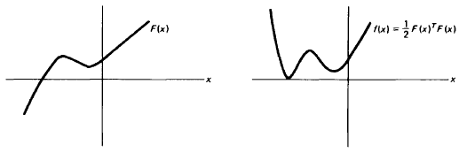

## Busca Linear

\[ x_{k+1} = x_k + \lambda_k p_k \]

- Calcular \(J(x_k)\) ou aproximação, fatorar para estimar se é singular e escolher \(p_k = -J(x_k)^{-1} F(x_k)\) ou \(p_k = -(J(x_k) + \mu_kI)^{-1} F(x_k)\)
- Queremos \(\lambda_k = 1\), buscar na direção \(p_k\) até satisfazer condição de Armijo

\[ f(x_{k+1}) < f(x_k) + 10^{-4} \lambda_k \nabla f(x_k)^T p_k\]

- Possibilidade de parada em mínimos locais de \(f\)

## Exemplo Didático - Interpolação C<sup>1</sup>

| \(i\) | \(k_i\) | \(c_i\) | \(c'_i\) | \(c''_i\) | \(f_i\) | \(\Sigma_i\) | \(a_i\) | \(b_i\) |
| --- | --- | --- | --- | --- | --- | --- | --- | --- |
| 0 | 0 | 10 | -1 | 0 | - | - | - | - |
| 1 | 5 | 6 | -0,65 | 0,2377 | 42,8329 | 1,7228 | 0 | -32,8329 |
| 2 | 7 | 5 | -0,4167 | 0,0687 | 4,3708 | 0,2761 | -0,3841 | 7,6611 |
| 3 | 10 | 4 | -0,2667 | 0,0135 | 6,7353 | 0,7565 | -0,0828 | 3,6849 |
| 4 | 15 | 3 | -0,1 | 0,0071 | 21,6273 | 0,3434 | 0,7143 | -14,7920 |
| 5 | \(\infty\) | 0 | 0 | 0 | 7,0345 | 1,63922 | 0 | 0 |

## Exemplo Didático - Interpolação C<sup>1</sup>

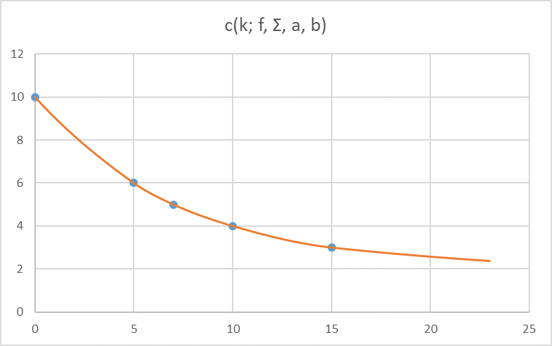

## Exemplo Didático - Interpolação C<sup>1</sup>

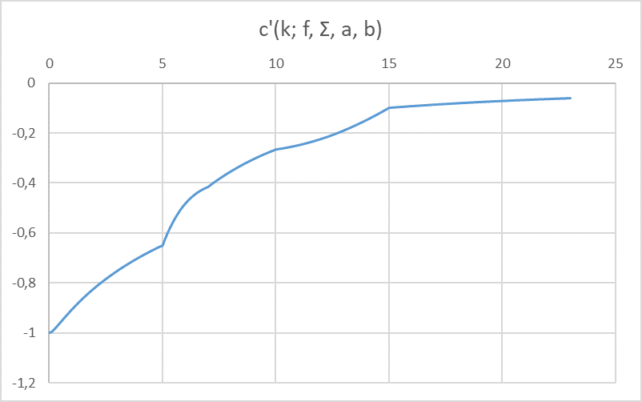

## Exemplo Didático - Interpolação C<sup>1</sup>

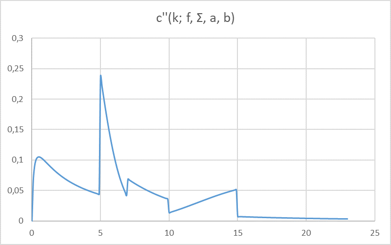

## Exemplo Didático - 2 Iterações

| \(i\) | \(k_i\) | \(c_i\) | \(c'_i\) | \(c''_i\) | \(f_i\) | \(\Sigma_i\) | \(a_i\) | \(b_i\) |
| --- | --- | --- | --- | --- | --- | --- | --- | --- |
| 0 | 0 | 10 | -1 | 0 | - | - | - | - |
| 1 | 5 | 6 | -0,5836 | 0,0831 | 11,9785 | 1,1276 | 0 | -1,9785 |
| 2 | 7 | 5 | -0,4178 | 0,0719 | 11,0702 | 0,6774 | 0,2145 | -1,4301 |
| 3 | 10 | 4 | -0,2683 | 0,0362 | 6,0587 | 0,6802 | -0,1275 | 4,5872 |
| 4 | 15 | 3 | -0,1492 | 0,0123 | 7,6183 | 0,8350 | -0,0396 | 2,5950 |
| 5 | \(\infty\) | 0 | 0 | 0 | 8,9408 | 1,2568 | 0 | 0 |

## Exemplo Didático - 2 Iterações

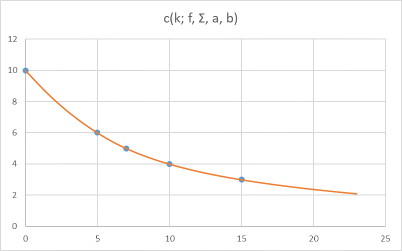

## Exemplo Didático - 2 Iterações

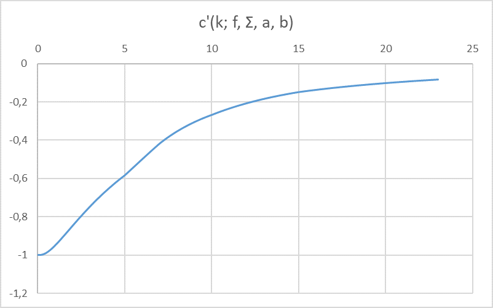

## Exemplo Didático - 2 Iterações

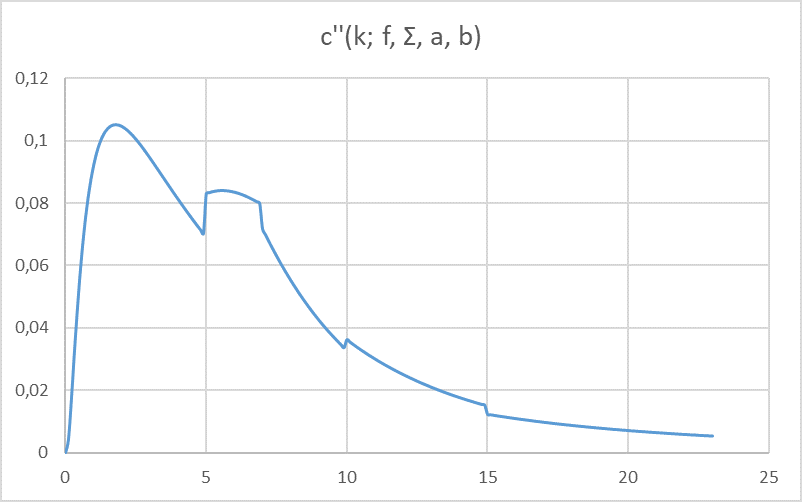

## Exemplo Didático - Interpolação C<sup>2</sup>

| \(i\) | \(k_i\) | \(c_i\) | \(c'_i\) | \(c''_i\) | \(f_i\) | \(\Sigma_i\) | \(a_i\) | \(b_i\) |
| --- | --- | --- | --- | --- | --- | --- | --- | --- |
| 0 | 0 | 10 | -1 | 0 | - | - | - | - |
| 1 | 5 | 6 | -0,5756 | 0,0726 | 11,0033 | 1,0798 | 0 | -1,0033 |
| 2 | 7 | 5 | -0,4233 | 0,0763 | 12,0994 | 0,6586 | 0,2687 | -2,6485 |
| 3 | 10 | 4 | -0,2639 | 0,0351 | 6,2378 | 0,6578 | -0,1162 | 4,4631 |
| 4 | 15 | 3 | -0,1542 | 0,0129 | 6,8521 | 0,7754 | -0,0732 | 3,4853 |
| 5 | \(\infty\) | 0 | 0 | 0 | 9,1232 | 1,2265 | 0 | 0 |

## Exemplo Didático - Interpolação C<sup>2</sup>

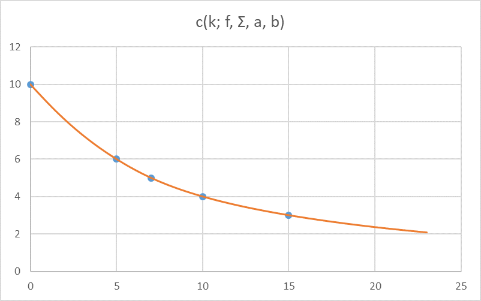

## Exemplo Didático - Interpolação C<sup>2</sup>

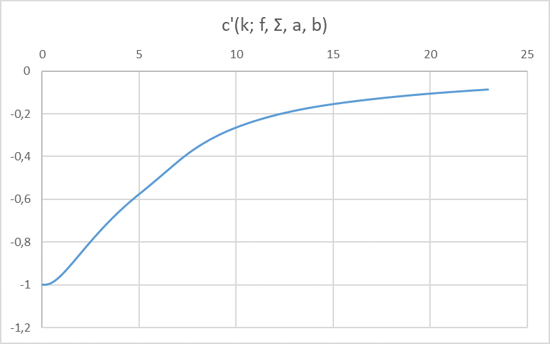

## Exemplo Didático - Interpolação C<sup>2</sup>

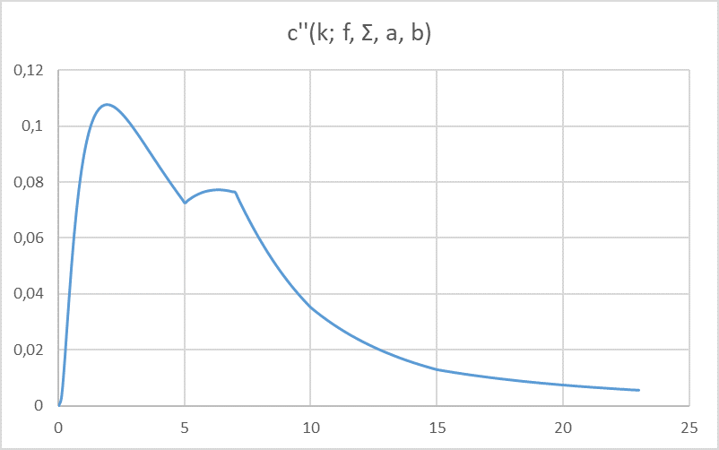

## Conclusões

- Apesar do crescimento rápido de equações na interpolação C<sup>2</sup> não iterativa, pode ser usado nas aplicações mostradas
- Sucesso do método ainda depende de pontos iniciais, e pode não ser consistente para novos dados diários, mas é uma alternativa a ser considerada
- Sistema completo da interpolação C<sup>2</sup> pode ser considerado para demonstração da unicidade da solução
- Resultados pelo pacote `nleqslv` muito superiores à implementação em VBA
- Considerar métodos que se reiniciam ao parar em mínimos locais para estudos futuros

## Códigos

A monografia completa, esta apresentação, as funções criadas e os códigos para gerar os gráficos estão disponíveis em

https://danielmoralesx.github.io/kahale_interp_vol/

Obrigado!